# Homework2

JiaRuoyu

2/7/2018

# question1

## (a)

$$L(\theta)=\prod_{i=1}^np(x_i;\theta)=\prod_{i=1}^n\frac{1}{\pi[1+(x_i-\theta)^2]}=\frac{1}{\pi^n}\prod_{i=1}^n\frac{1}{1+(x_i-\theta)^2}$$

$$l(\theta)=\ln L(\theta)=\ln (\frac{1}{\pi^{n}}\prod_{i=1}^n\frac{1}{1+(x_i-\theta)^2})= -n\ln \pi-\sum_{i=1}^n\ln (1+(\theta-x_i)^2)$$
$$l'(\theta)=(-\sum_{i=1}^n\ln (1+(\theta-x_i)^2))'=-\sum_{i=1}^n\frac{2(\theta-x_i)}{1+(\theta-x_i)^2}=-2\sum_{i=1}^n\frac{\theta-x_i}{1+(\theta-x_i)^2}$$

$$l''(\theta)=-2\sum_{i=1}^n\frac{1+(\theta-x_i)^2-2(\theta-x_i)^2}{[1+(\theta-x_i)^2]^2}=-2\sum_{i=1}^n\frac{1-(\theta-x_i)^2}{[1+(\theta-x_i)^2]^2}$$
$$P(x)=\frac{1}{\pi(1+x^2)}$$
$$P'(x)=-\frac{1}{\pi}~\frac{2x}{(1+x^2)^2}$$

$$P'(x)^2=\frac{4}{\pi^2}~\frac{x^2}{(1+x^2)^4}$$

$$I(\theta)=\frac{4n}{\pi}\int_{-\frac{\pi}{2}}^{\frac{\pi}{2}}\frac{\tan^2\beta}{(1+tan^2\beta)^3}\frac{1}{\\cos^2\beta}d\beta=\frac{4n}{\pi}\int_{-\frac{\pi}{2}}^{\frac{\pi}{2}}\sin^2\beta\cos^2\beta~d\beta=\frac{4n}{\pi}\int_{-\frac{\pi}{2}}^{\frac{\pi}{2}}\sin^2\beta(1-\sin^2\beta)~d\beta=\frac{4n}{\pi}\int_{-\frac{\pi}{2}}^{\frac{\pi}{2}}\sin^2\beta-\sin^4\beta~d\beta$$

*As $1-\cos2\beta=2\sin^2\beta$, then we have*

$$\int_{-\frac{\pi}{2}}^{\frac{\pi}{2}}\sin^4\beta~d\beta=\frac{1}{4}\int_{-\frac{\pi}{2}}^{\frac{\pi}{2}}(1-\cos2\beta)^2d\beta=\frac{1}{4}\int_{-\frac{\pi}{2}}^{\frac{\pi}{2}}\cos^22\beta-2\cos2\beta+1~d\beta$$
$$=\frac{1}{4}\int_{-\frac{\pi}{2}}^{\frac{\pi}{2}}\frac{\cos4\beta}{2}-2\cos2\beta+\frac{3}{2}~d\beta=\frac{1}{4}(\frac{1}{8}\sin4\beta-\sin2\beta+\frac{3}{2}\beta)|_{-\frac{\pi}{2}}^{\frac{\pi}{2}}~=\frac{3\pi}{8}$$

*Finally we have:*
$$I(\theta)=\frac{4n}{\pi}(\frac{\pi}{2}-\frac{3\pi}{8})=\frac{n}{2}$$

## (b)

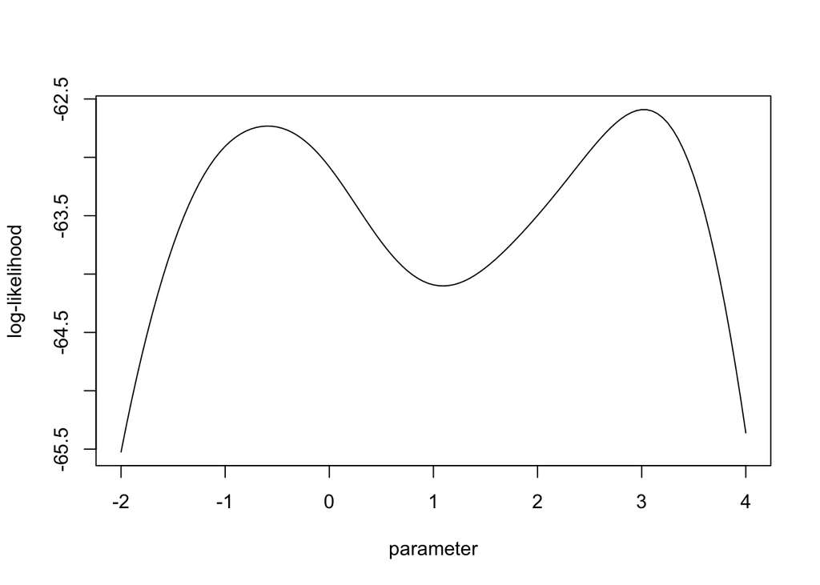

```
## [1] 3.021345
```

```
## [1] -0.5914735
```

```
## [1] -0.5914735
```

```
## [1] 3.021345
```

```
## [1] 3.021345
```

```
## [1] 3.021345
```

```
## [1] 3.021345
```

```
## [1] 3.021345
```

```
## [1] 3.021345
```

## (c)

For each vector, vector[1] is the estimation when $\alpha=1$, vector[2] is the estimation when $\alpha=0.64$, vector[3] is the estimation when $\alpha=0.25$

```
## [1] -0.5914827  3.0213332 -0.5915249
```

```
## [1] -0.5914791 -0.5914824 -0.5915051
```

```
## [1] -0.5914717 -0.5914659 -0.5914218
```

```
## [1] 3.021345 3.021345 3.021344
```

```
## [1] 3.021345 3.021338 3.021345
```

```
## [1] 3.021345 3.021328 3.021344
```

```
## [1] 3.021335 3.021345 3.021343
```

```
## [1] -0.5914408 -0.5914885  3.0213434
```

```
## [1] -0.5914796  3.0213451  3.0213435
```

## (d)

```
## [1] -0.5915031
```

```
## [1] -0.5915022
```

```
## [1] -0.5914394
```

```
## [1] 3.021336
```

```
## [1] 3.021354
```

```
## [1] 3.021359
```

```
## [1] 3.021358
```

```
## [1] 3.021356
```

```
## [1] 3.021357
```

## (e)

speed: The speed of convergence of Newton method is the fastest. And the speed of Fisher method and Fixed-Point method is normal.

stability: The stability of the Newton method is the worst. The stability of fisher method is good. And the stability of Fixed-Point method depends on $\alpha$, the smaller the $\alpha$ is, the better stability will be.

# question 2

## (a)

*As $p(x;\theta)= \frac{1-\cos(x-\theta)}{2\pi},~0\leqslant x\leqslant2\pi,~\theta\in(-\pi,\pi),$ then we have*
$$L(\theta)=\prod_{i=1}^n\frac{1-\cos(x_i-\theta)}{2\pi}=\frac{1}{(2\pi)^n}\prod_{i=1}^n[1-\cos(x_i-\theta)]$$

$$l(\theta)=-n\log(2\pi)+\sum_{i=1}^n\log[1-\cos(x_i-\theta)]$$

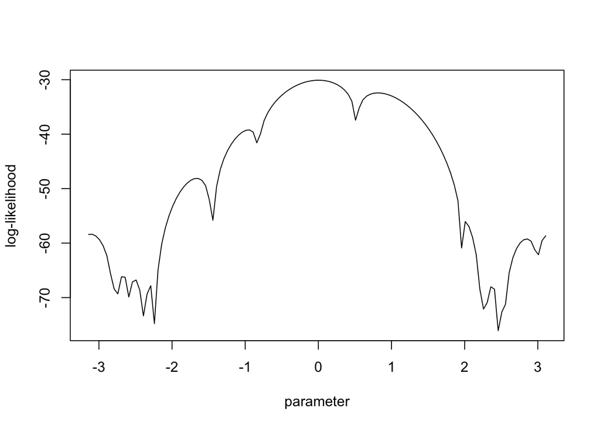

## (b)

$$E(x|\theta)=\int_{0}^{2\pi}xP(x|\theta)~dx=\int_{0}^{2\pi}x~\frac{1-\cos(x-\theta)}{2\pi}~dx=\frac{1}{2\pi}\int_{0}^{2\pi}x-x\cos(x-\theta)~dx=\pi-\frac{1}{2\pi}\int_{0}^{2\pi}x\cos(x-\theta)~dx$$
$$\int_{0}^{2\pi}x\cos(x-\theta)~dx=x\sin(x-\theta)|_0^{2\pi}-\int_{0}^{2\pi}\sin(x-\theta)~dx=-2\pi\sin\theta+\cos(x-\theta)|_0^{2\pi} =-2\pi\sin\theta$$
$$E(x|\theta)=\pi+\sin\theta=\bar{x}$$
$$\hat{\theta}_{moment}=\arcsin(\bar{x}-\pi)$$

```
## [1] 0.09539407
```

## (c)

```
## [1] 0.003118157
```

## (d)

```
## [1] -2.668857
```

```
## [1] 2.848415
```

## (e)

| 1 | 2 | 3 | 4 | 5 | 6 | 7 | 8 | 9 | 10 | 11 | 12 | 13 | 14 | 15 | 16 | 17 | 18 | 19 | 20 | 21 | 22 | 23 | 24 | 25 | 26 | 27 | 28 | 29 | 30 | … |
| --- | --- | --- | --- | --- | --- | --- | --- | --- | --- | --- | --- | --- | --- | --- | --- | --- | --- | --- | --- | --- | --- | --- | --- | --- | --- | --- | --- | --- | --- | --- |
| -2.38382 |  |  |  |  |  |  |  |  |  |  |  |  |  |  |  |  |  |  |  |  |  |  |  |  |  |  |  |  |  | … |
| -2.22595 |  |  |  |  |  |  |  |  |  |  |  |  |  |  |  |  |  |  |  |  |  |  |  |  |  |  |  |  |  | … |
| 2.47854 |  |  |  |  |  |  |  |  |  |  |  |  |  |  |  |  |  |  |  |  |  |  |  |  |  |  |  |  |  | … |
| 2.51012 |  |  |  |  |  |  |  |  |  |  |  |  |  |  |  |  |  |  |  |  |  |  |  |  |  |  |  |  |  | … |
| 2.22595 |  |  |  |  |  |  |  |  |  |  |  |  |  |  |  |  |  |  |  |  |  |  |  |  |  |  |  |  |  | … |
| 2.25753 |  |  |  |  |  |  |  |  |  |  |  |  |  |  |  |  |  |  |  |  |  |  |  |  |  |  |  |  |  | … |
| -2.79428 |  |  |  |  |  |  |  |  |  |  |  |  |  |  |  |  |  |  |  |  |  |  |  |  |  |  |  |  |  | … |
| -2.76271 |  |  |  |  |  |  |  |  |  |  |  |  |  |  |  |  |  |  |  |  |  |  |  |  |  |  |  |  |  | … |
| 2.32067 |  |  |  |  |  |  |  |  |  |  |  |  |  |  |  |  |  |  |  |  |  |  |  |  |  |  |  |  |  | … |
| 2.44697 |  |  |  |  |  |  |  |  |  |  |  |  |  |  |  |  |  |  |  |  |  |  |  |  |  |  |  |  |  | … |
| 2.2891 | 2.35225 | 2.38382 | 2.4154 |  |  |  |  |  |  |  |  |  |  |  |  |  |  |  |  |  |  |  |  |  |  |  |  |  |  | … |
| -2.35225 | -2.2891 | -2.25753 |  |  |  |  |  |  |  |  |  |  |  |  |  |  |  |  |  |  |  |  |  |  |  |  |  |  |  | … |
| -2.32067 |  |  |  |  |  |  |  |  |  |  |  |  |  |  |  |  |  |  |  |  |  |  |  |  |  |  |  |  |  | … |
| -2.57326 | -2.54169 | -2.47854 | -2.4154 |  |  |  |  |  |  |  |  |  |  |  |  |  |  |  |  |  |  |  |  |  |  |  |  |  |  | … |
| -2.51012 | -2.44697 |  |  |  |  |  |  |  |  |  |  |  |  |  |  |  |  |  |  |  |  |  |  |  |  |  |  |  |  | … |
| -2.73113 | -2.69956 | -2.66799 |  |  |  |  |  |  |  |  |  |  |  |  |  |  |  |  |  |  |  |  |  |  |  |  |  |  |  | … |
| -2.63641 | -2.60484 |  |  |  |  |  |  |  |  |  |  |  |  |  |  |  |  |  |  |  |  |  |  |  |  |  |  |  |  | … |
| 2.54169 | 2.57326 | 2.63641 | 2.66799 | 2.73113 | 2.76271 | 2.85743 | 2.889 | 2.92058 | 2.98372 |  |  |  |  |  |  |  |  |  |  |  |  |  |  |  |  |  |  |  |  | … |
| 2.60484 | 2.69956 | 2.79428 | 2.82585 | 2.95215 |  |  |  |  |  |  |  |  |  |  |  |  |  |  |  |  |  |  |  |  |  |  |  |  |  | … |
| -3.14159 | -3.11002 | -3.07845 | -3.04687 | -3.0153 | -2.95215 | -2.92058 | -2.889 | -2.85743 | -2.82585 |  |  |  |  |  |  |  |  |  |  |  |  |  |  |  |  |  |  |  |  | … |
| -2.98372 |  |  |  |  |  |  |  |  |  |  |  |  |  |  |  |  |  |  |  |  |  |  |  |  |  |  |  |  |  | … |
| 3.0153 | 3.04687 | 3.07845 | 3.11002 | 3.14159 |  |  |  |  |  |  |  |  |  |  |  |  |  |  |  |  |  |  |  |  |  |  |  |  |  | … |
| 2.1628 |  |  |  |  |  |  |  |  |  |  |  |  |  |  |  |  |  |  |  |  |  |  |  |  |  |  |  |  |  | … |
| 1.97336 | 2.13123 |  |  |  |  |  |  |  |  |  |  |  |  |  |  |  |  |  |  |  |  |  |  |  |  |  |  |  |  | … |
| 2.00494 | 2.06808 | 2.19438 |  |  |  |  |  |  |  |  |  |  |  |  |  |  |  |  |  |  |  |  |  |  |  |  |  |  |  | … |
| 2.09966 |  |  |  |  |  |  |  |  |  |  |  |  |  |  |  |  |  |  |  |  |  |  |  |  |  |  |  |  |  | … |
| 2.03651 |  |  |  |  |  |  |  |  |  |  |  |  |  |  |  |  |  |  |  |  |  |  |  |  |  |  |  |  |  | … |
| -1.43661 |  |  |  |  |  |  |  |  |  |  |  |  |  |  |  |  |  |  |  |  |  |  |  |  |  |  |  |  |  | … |
| -2.1628 | -2.13123 | -2.09966 | -1.91021 | -1.87864 | -1.84707 | -1.81549 | -1.72077 | -1.5629 | -1.49976 |  |  |  |  |  |  |  |  |  |  |  |  |  |  |  |  |  |  |  |  | … |
| -2.19438 | -2.06808 | -2.03651 | -2.00494 | -1.97336 | -1.94179 | -1.78392 | -1.75235 | -1.6892 | -1.65762 | -1.62605 | -1.59448 | -1.53133 | -1.46818 |  |  |  |  |  |  |  |  |  |  |  |  |  |  |  |  | … |
| -1.18402 |  |  |  |  |  |  |  |  |  |  |  |  |  |  |  |  |  |  |  |  |  |  |  |  |  |  |  |  |  | … |
| -1.40503 | -1.37346 | -1.34189 | -1.31031 | -1.27874 | -1.24716 | -1.21559 | -1.15244 | -1.12087 | -1.0893 | -1.05772 | -1.02615 | -0.99457 | -0.963 | -0.93143 | -0.89985 | -0.86828 | -0.83671 |  |  |  |  |  |  |  |  |  |  |  |  | … |
| 0.52097 | 0.55254 | 0.58412 | 0.61569 | 0.64726 | 0.67884 | 0.71041 | 0.74198 | 0.77356 | 0.80513 | 0.83671 | 0.86828 | 0.89985 | 0.93143 | 0.963 | 0.99457 | 1.02615 | 1.05772 | 1.0893 | 1.12087 | 1.15244 | 1.18402 | 1.21559 | 1.24716 | 1.27874 | 1.31031 | 1.34189 | 1.37346 | 1.40503 | 1.43661 | … |
| -0.80513 | -0.77356 | -0.74198 | -0.71041 | -0.67884 | -0.64726 | -0.61569 | -0.58412 | -0.55254 | -0.52097 | -0.48939 | -0.45782 | -0.42625 | -0.39467 | -0.3631 | -0.33152 | -0.29995 | -0.26838 | -0.2368 | -0.20523 | -0.17366 | -0.14208 | -0.11051 | -0.07893 | -0.04736 | -0.01579 | 0.01579 | 0.04736 | 0.07893 | 0.11051 | … |

# question3

## (a)

The start point is (1200,0.2), and we get $K=1049.4038970,~r=0.1182693$

```
##              [,1]
## [1,] 1049.4038970
## [2,]    0.1182693
```

## (b)

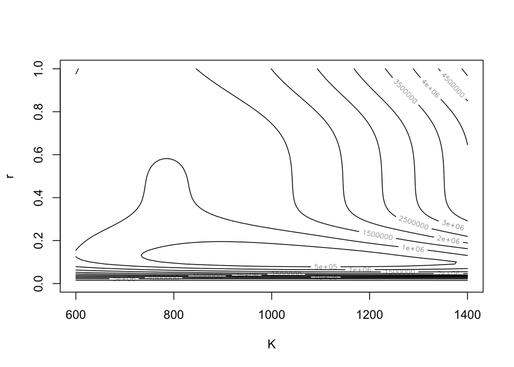

## (c)

```
##             [,1]
## [1,] 820.5349872
## [2,]   0.1926176
## [3,]   0.6441323
```

```
##               [,1]          [,2]          [,3]
## [1,]  6.248530e+04 -9.054089e+00  1.051866e-07
## [2,] -9.054089e+00  3.974068e-03 -5.353628e-11
## [3,]  1.051866e-07 -5.353628e-11  2.074532e-02
```

The start point is (1200,0.2,0.5), and we get $K=820.5349872,~r=0.1926176, ~\sigma=0.6441323$.  
The variance of $K,~r,~\sigma$ are $6.248530\cdot10^{4},~3.974068\cdot10^{-3},~2.074532\cdot10^{-2}$